# The Scenario

"More than 38,000 people die every year in crashes on U.S. roadways. The U.S. traffic fatality rate is 12.4 deaths per 100,000 inhabitants. An additional 4.4 million are injured seriously enough to require medical attention."

This brings with it the utmost importance to introduce autonomous vehicles to keep the people safe.  
However, to truly keep the people safe, the vehicles must be able to recognize the traffic signs and act accordingly.

You are an AI Engineer with DriveSafe, a company focuses on building autonomous vehicles.  
Your current task is to train the vehicles to recognize the traffic signs.

Source: https://www.asirt.org/safe-travel/road-safety-facts/

# Tips for working on this project

You will be using these three concepts to be able to successfully complete this project:

1. Deep Learning models
2. AI Project Cycle
3. AI Ethics

If needed, please revise your notes on these topics.

# Section 1: Understand the Problem

One of the key points of solving an AI problem is to understand the problem statement correctly.  
You need to understand what is the correct problems that you are solving.  
You want to solve the root problem and not the symptoms.  
To do that, you can use tools like 5 Whys, decomposition, and Fish-bone diagram.  
You can then write your problem statement.  
It may include helpful information, like who is affected, what is the problem, where is it happening, and when does it happen.

Based on the scenario above, write your problem statement in the cell below!

```python
# Your answers here!

# Many peopled get injured and died in traffic accidents.
# Autonomous vehicles can help to reduce the number of traffic accidents.
# However, to make a safer trip on autonomous vehicles, we need to have a good computer vision system.
# Therefore, it is important to develop an AI model that can automatically recognize the traffic sign.
```

# Section 2: Data Acquisition

Data is the main ingredient for AI model.  
For a typical scenario for autonomous vehicles, where can you find your data?  
Write your answer in the cell below.

In this scenario, you are given a few files.  
These files are downloaded from: https://www.kaggle.com/meowmeowmeowmeowmeow/gtsrb-german-traffic-sign

```python
# Your answers here!

# There are many sources that we can use.
# There are online sources like Kaggle.
# We can also capture our own data, just like what Google has been doing.
```

## The AI Ethics of Handling Data

AI Ethics is a vital component in our daily life.  
What areas of AI Ethics are important in this scenario?  
What are the implications of ignoring the AI Ethics?  
More importantly, what can you do to uphold the AI Ethics in this scenario?  
Write your answer in the cell below.

```python
# Your answer here!

# Areas of AI Ethics include: privacy, bias, copyrights.
# The implications of ignoring AI Ethics include: legal issues (fined under GDPR)
# What can you do to improve the AI Ethics?
# You can anonymize the data (to prevent recognizable photos of people),
# You do not use copyrighted photos (you would need to ask for written approvals)
# You can check through the dataset to ensure there is no bias or misrepresentation
# (example certain district having more stop signs)
```

# Import libraries and insert the file

```python
import numpy as np
import pandas as pd
import matplotlib.pyplot as plt
import cv2
import tensorflow as tf
from PIL import Image
import os
from sklearn.model_selection import train_test_split

# Uncomment the below if your tensorflow is 1.x
# from keras.utils import to_categorical
# from keras.models import Sequential, load_model
# from keras.layers import Conv2D, MaxPool2D, Dense, Flatten, Dropout

# Uncomment the below if your tensorflow is 2.x
from tensorflow.keras.utils import to_categorical
from tensorflow.keras.models import Sequential, load_model
from tensorflow.keras.layers import Conv2D, MaxPool2D, Dense, Flatten, Dropout
```

# Section 3: Data Exploration

Let's prepare the data so that it's ready for the modeling.

```python
# Let's initialize some variables
data = []
labels = []
classes = 43
current_path = os.getcwd()
```

```python
# Retrieve the images and their labels
for i in range(classes):
    path = os.path.join(current_path,'train',str(i))
    images = os.listdir(path)

    for a in images:
        try:
            image = Image.open(path + '\\'+ a)
            image = image.resize((30,30))
            image = np.array(image)
            data.append(image)
            labels.append(i)
        except:
            print("Error loading image")
```

## Train Test Split

Do you still remember how to split your data into training data and testing data?  
For easy reference, you need to create: X_train, X_test, y_train, y_test

What ratio will you use to do the split?  
Common ratios are 70:30 and 80:20.

```python
# Convert lists into numpy arrays
data = np.array(data)
labels = np.array(labels)

print(data.shape, labels.shape)

# Your answers here!
#Split into training data and testing data
X_train, X_test, y_train, y_test = train_test_split(data, labels, test_size=0.2)

print(X_train.shape, X_test.shape, y_train.shape, y_test.shape)
```

```
(39209, 30, 30, 3) (39209,)
(31367, 30, 30, 3) (7842, 30, 30, 3) (31367,) (7842,)
```

## One Hot Encoding

Usually, numbers in Machine Learning algorithms mean ranking or importance.  
However, some input data do not have any ranking. This may lead to poor predictions.  
Therefore, we need to use one hot encoding to solve the above problem.  
Do you still remember how to do that?  
Write your answer in the cell below.

```python
# Your answers here!
# Convert the labels into one hot encoding
y_train = to_categorical(y_train, 43)
y_test = to_categorical(y_test, 43)
```

# Section 4: Modeling

We will be building our Neural Network.  
Do you still remember how it looks like?

There are different layers, each with different purposes:

1. Conv2D : it is a 2D convolution layer to produce a tensor of outputs.
2. MaxPool2D : it reduces the size by sampling the maximum value in the region.
3. Dropout : it drops some neural network connections to prevent overfitting.

In the cell below, create your own Neural Network model.  
You can experiment by mixing layers of Conv2D, MaxPool2D, and Dropout, of varying parameters.

```python
# Your answers here!

#Build the model
model = Sequential()
model.add(Conv2D(filters=32, kernel_size=(3,3), activation='relu', input_shape=X_train.shape[1:]))
model.add(MaxPool2D(pool_size=(2, 2)))
model.add(Dropout(rate=0.2))

model.add(Conv2D(filters=64, kernel_size=(3, 3), activation='relu'))
model.add(MaxPool2D(pool_size=(2, 2)))
model.add(Dropout(rate=0.2))

model.add(Conv2D(filters=128, kernel_size=(3, 3), activation='relu'))
model.add(MaxPool2D(pool_size=(2, 2)))
model.add(Dropout(rate=0.2))

model.add(Flatten())
model.add(Dense(256, activation='relu'))
model.add(Dropout(rate=0.3))

model.add(Dense(43, activation='softmax'))
```

## Compilation

You will need to determine what is the metrics for your model.  
You've learned about binary_crossentropy and categorical_crossentropy.  
You've also learned about the different optimizers (ADAM, SGD, etc).

```python
# Your answers here!
# Compile the model
model.compile(loss='categorical_crossentropy', optimizer='adam', metrics=['accuracy'])
```

## How long do you want to train your model?

You can determine how many cycles you want to run.  
In Machine Learning, a cycle is called an epoch.  
Theoretically, the more epoch will lead to higher acuracy. However, it may lead to overfitting.  
You can also determine the size of each batch. The bigger the batch size, the more data it will be tested at one time.  
However, it will be more taxing on your computing resources too.

In the cell below, indicate your epoch, batch_size, and the code for model.fit().

```python
# Your answers here!
epochs = 20
history = model.fit(X_train, y_train, batch_size=32, epochs=epochs, validation_data=(X_test, y_test))
```

# Section 5: Evaluation

We want to check the performance of our model.  
We want to know the accuracy of the results.  
Do you know how to identify underfitting and overfitting (if there is any?) from the below graphs?

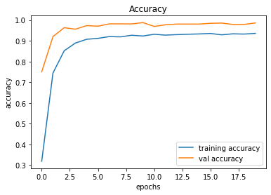

```python
# Your answers here!

#plot the graph for accuracy
plt.plot(history.history['accuracy'], label='training accuracy')
plt.plot(history.history['val_accuracy'], label='val accuracy')
plt.title('Accuracy')
plt.xlabel('epochs')
plt.ylabel('accuracy')
plt.legend()
plt.show()
```

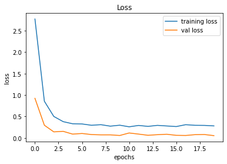

```python
# Your answers here!

#plot the graph for loss
plt.plot(history.history['loss'], label='training loss')
plt.plot(history.history['val_loss'], label='val loss')
plt.title('Loss')
plt.xlabel('epochs')
plt.ylabel('loss')
plt.legend()
plt.show()
```

## Evaluate using Test Dataset

Just now we evaluate the model using the data from the training dataset.  
Now we will evaluate using Test.csv, which is the data that the model has never seen before.

```python
# test accuracy on test dataset
from sklearn.metrics import accuracy_score

y_test = pd.read_csv('Test.csv')

labels = y_test["ClassId"].values
imgs = y_test["Path"].values

data=[]
```

```python
for img in imgs:
    image = Image.open(img)
    image = image.resize((30,30))
    data.append(np.array(image))

X_test=np.array(data)

pred = np.argmax(model.predict(X_test), axis=-1)
```

## Check accuracy

Use accuracy_score from sklearn.metrics to compare the score between the actual labels and predictions.

```python
# Your answers here!
# Accuracy with the test data
from sklearn.metrics import accuracy_score
print(accuracy_score(labels, pred))
```

```
0.9428345209817894
```

# What is your best model?

In order to get best model, you will need to modify the parameters.  
Look back at the models in section 4, can you fine tune it better?  
What is your best model? How does it fare?

# Section 6: Deployment

What makes a good deployment?  
It has to be useful and easy to use.  
It needs to be updated frequently and easily.  
Deployment can be on-premise or online.

In the cell below, write down your suggestions on how you can deploy this AI model.

```python
# Your answers here!

# Since this is used on the autonomous vehicle, it will be used on the embedded system of the car.
# The camera feeds from the camera will be captured and analyzed by the model directly.
```

# Other Reading Materials